# The Effect of /r/WallStreetBets on the Stock Market

[figure not shown]

**After reading in Bloomberg Businessweek that the subreddit r/WallStreetBets was likely behind some interesting stock trends with Virgin Galactic (SPCE) and Power Plug (PLUG), I decided to explore these relation ships myself.**

- [Bloomberg Article](https://www.bloomberg.com/news/articles/2020-02-26/reddit-s-profane-greedy-traders-are-shaking-up-the-stock-market)

```python
import pandas as pd
from pandas.io.json import json_normalize as jnorm
import numpy as np
import requests
import json
from datetime import datetime
import traceback
import re
from datetime import datetime
from datetime import timedelta
```

### The first order of business is to retrieve all the posts and comments from the subreddit in order to track mentions of these stocks.

**I put together a function to retrieve posts or comments from subreddit within any time period (last 30 days for example) and save it in a structured CSV format.**

```python
#subreddit = "wallstreetbets"


def downloadFromSubreddit(filename, object_type, days_back,
                          subreddit):  #after_date format: 100 days as '100d'

    url = "https://api.pushshift.io/reddit/{}/search?limit=1000&sort=desc&subreddit={}&before="

    start_time = datetime.utcnow()

    print(f"Saving {object_type}s to {filename}")

    count = 0
    handle = open(filename, 'w')
    starttime = start_time.timestamp()
    previous_epoch = int(starttime)
    stoptime = int(starttime) - int(days_back) * 86400
    while previous_epoch > stoptime:
        new_url = url.format(object_type, subreddit) + str(previous_epoch)
        json = requests.get(
            new_url, headers={'User-Agent': "/u/isaacwino"})
        json_data = json.json()
        if 'data' not in json_data:
            break
        objects = json_data['data']
        if len(objects) == 0:
            break

        for object in objects:
            previous_epoch = object['created_utc'] - 1
            count += 1
            if object_type == 'comment':
                try:
                    text = object['body']
                    if text != '[removed]':
                        handle.write(str(object['score']))
                        handle.write("\t")
                        handle.write(
                            datetime.fromtimestamp(
                                object['created_utc']).strftime(
                                    "%Y-%m-%d-%H-%M-%S"))
                        handle.write("\t")
                        textASCII = text.encode(encoding='ascii',
                                                errors='ignore').decode()
                        textASCII = re.sub('\n', ' ', textASCII)
                        textASCII = re.sub('\t', ' ', textASCII)
                        handle.write(textASCII)
                        handle.write("\n")
                except Exception as err:
                    print(
                        f"Couldn't print comment: https://www.reddit.com{object['permalink']}"
                    )
                    print(traceback.format_exc())
            elif object_type == 'submission':
                if object['is_self']:
                    if 'selftext' not in object:
                        continue
                    try:
                        text = object['selftext']
                        if text != '[removed]':
                            handle.write(str(object['score']))
                            handle.write("\t")
                            handle.write(
                                datetime.fromtimestamp(
                                    object['created_utc']).strftime(
                                        "%Y-%m-%d-%H-%M-%S"))
                            handle.write("\t")
                            textASCII = text.encode(encoding='ascii',
                                                    errors='ignore').decode()
                            textASCII = re.sub('\n', ' ', textASCII)
                            textASCII = re.sub('\t', ' ', textASCII)
                            handle.write(textASCII)
                            handle.write("\n")
                    except Exception as err:
                        print(f"Couldn't print post: {object['url']}")
                        print(traceback.format_exc())

        print("Saved {} {}s through {}".format(
            count, object_type,
            datetime.fromtimestamp(previous_epoch).strftime("%Y-%m-%d")))

    print(f"Saved {count} {object_type}s")
    handle.close()



#USAGE EXAMPLE:
#downloadFromSubreddit("comments_90days.csv", "comment", '90', 'wallstreetbets')
```

### Now I load the comments into the notebook so I can begin analyzing them.

```python
comments = pd.read_csv('comments_90days.csv',
                       sep='\t',
                       names=['Score', 'Time', 'Comment'],
                       lineterminator='\n')
```

```python
#Convert the Timestamp Column into a time index for the dataframe
comments.Time = pd.to_datetime(comments.Time, format='%Y-%m-%d-%H-%M-%S')
comments = comments.set_index(pd.to_datetime(comments['Time']))
comments.drop('Time', axis=1, inplace=True)
```

```python
#Take a gander at that pretty dataframe
comments.head()
```

| Time | Score | Comment |
| --- | --- | --- |
| 2020-02-28 19:04:31 | 2 | Probably not, depending on expiration. No one ... |
| 2020-02-28 19:04:25 | 2 | You call the fastest correction in history a c... |
| 2020-02-28 19:04:22 | 1 | Haha I bought my puts when Chinese ppl were dy... |
| 2020-02-28 19:04:21 | 1 | Probably for the best but I bet theyd print co... |
| 2020-02-28 19:04:20 | 1 | 3/20 exp. I ain't going nowhere\r |

### Now I need to count the frequency, so I wrote two functions:

- **word_freq** will count the frequency of any word in an array of strings
- **getMentionsOverTime** will use word_freq to get mentions of a stock over time and either returns a DF or a plot

```python
#Counts the frequency of the stock ticker name (uppercase and lowercase mentions)
import re


def word_freq2(array, word):
    input_string = array.to_string(index=False)
    input_string = input_string.lower()
    count = sum(1 for _ in re.finditer(r'\b%s\b' %
                                       re.escape(word.lower()), input_string))
    return count
```

```python
#Gets the mentions over time in prefered time interval
def getMentionsOverTime(stock,interval = 'd', return_df = False):
    term_df = pd.DataFrame(columns = ["Time", 'Mentions of {}'.format(stock)])
    time = []
    mentions = []
    commentsGrouped = comments.groupby(pd.Grouper(freq=interval))

    for name, group in commentsGrouped.Comment:
        mentions.append(word_freq2(group, stock))
        time.append(name)

    term_df['Time'] = time
    term_df['Mentions of {}'.format(stock)] = mentions

    term_df.Time = pd.to_datetime(term_df.Time, format = '%Y-%m-%d-%H-%M-%S')
    term_df = term_df.set_index(pd.to_datetime(term_df['Time']))
    term_df.drop('Time', axis = 1, inplace = True)
    if return_df == False:
        return term_df.plot()
    else:
        return term_df
```

### Test the Functions on a few stocks

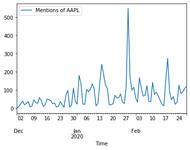

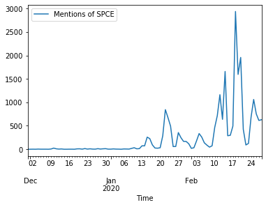

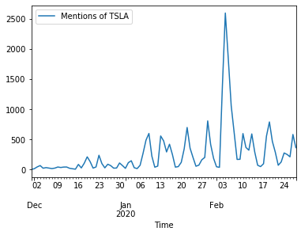

```python
getMentionsOverTime('AAPL')
getMentionsOverTime('SPCE')
getMentionsOverTime('TSLA')
```

```python
#Write to CSV

# AAPL_mentions = getMentionsOverTime('AAPL', return_df = True)
# TSLA_mentions = getMentionsOverTime('TSLA', return_df = True)
# AAPL_mentions.to_csv('AAPL_mentions_perday_90days.csv')
# TSLA_mentions.to_csv('TSLA_mentions_perday_90days.csv')
```

## Plot of SPCE Stockprice and PLUG Trading Volume with Mentions on /r/WallStreetBets

[figure not shown]

## Conclusion:

- Bloomberg Businessweek is likely correct and it seems stocks, like SPCE and PLUG, are uniquely popular on the subreddit.
- It appears that mentions of SPCE and PLUG predate their respective increases in stock price and trading volume.
- Correlation does not mean causation, but it seems plausible that a community of over 900,000 users can cause odd stock behaviors.
- Potentially, you could observe the subreddit for abnormal stock popularities to identify signals that stock might rise shortly.